# Model analyses

Author

Kendra Wyant

Published

June 14, 2024

### Set Up Environment

```r
suppressPackageStartupMessages(library(tidyverse))
suppressPackageStartupMessages(source("https://github.com/jjcurtin/lab_support/blob/main/format_path.R?raw=true"))
suppressPackageStartupMessages(library(tidyposterior))

path_models_lag <- format_path(str_c("studydata/risk/models/lag"))
path_shared <- format_path("studydata/risk/data_processed/shared")
path_processed <- format_path("studydata/risk/data_processed/lag")

options(knitr.kable.NA = '')
```

```r
test_metrics_0 <- read_csv(file.path(path_models_lag,
                                        "test_metrics_1week_0_v1_nested.csv"),
                              col_types = cols()) |>
  filter(.metric == "roc_auc") |>
  select(outer_split_num, "lag0" = .estimate)

test_metrics_24 <- read_csv(file.path(path_models_lag,
                                       "test_metrics_1week_24_v1_nested.csv"),
                             col_types = cols()) |>
  filter(.metric == "roc_auc") |>
  select(outer_split_num, "lag24" = .estimate)

test_metrics_72 <- read_csv(file.path(path_models_lag,
                                        "test_metrics_1week_72_v1_nested.csv"),
                              col_types = cols()) |>
  filter(.metric == "roc_auc") |>
  select(outer_split_num, "lag72" = .estimate)

test_metrics_168 <- read_csv(file.path(path_models_lag,
                                        "test_metrics_1week_168_v1_nested.csv"),
                              col_types = cols()) |>
  filter(.metric == "roc_auc") |>
  select(outer_split_num, "lag168" = .estimate)

test_metrics_336 <- read_csv(file.path(path_models_lag,
                                       "test_metrics_1week_336_v1_nested.csv"),
                             col_types = cols()) |>
  filter(.metric == "roc_auc") |>
  select(outer_split_num, "lag336" = .estimate)

test_metrics_all <- test_metrics_0 |>
  left_join(test_metrics_24, by = c("outer_split_num")) |>
  left_join(test_metrics_72, by = c("outer_split_num")) |>
  left_join(test_metrics_168, by = c("outer_split_num")) |>
  left_join(test_metrics_336, by = c("outer_split_num")) |>
  mutate(fold_num = rep(1:10, 3),
         repeat_num = c(rep(1, 10), rep(2, 10), rep(3, 10))) |>
  select(-outer_split_num)
```

#### Model evaluation

```r
# Repeated CV (id = repeat, id2 = fold within repeat)
# with a common variance:  statistic ~ model + (model | id2/id)
set.seed(101)
pp <- test_metrics_all |>
  rename(id = repeat_num,
         id2 = fold_num) |>
  perf_mod(formula = statistic ~ model + (1 | id2/id),
         transform = tidyposterior::logit_trans,  # for skewed & bounded AUC
         iter = 2000, chains = 4, adapt_delta = .99, # defaults but may increase to fix divergence issues
         family = gaussian,
)
```

```r
test_metrics_all_perf <- test_metrics_all |>
  summarize(across(`lag0`:`lag336`,
                   list(median = median,
                        IQR = IQR)))

glimpse(test_metrics_all_perf)
```

```
Rows: 1
Columns: 10
$ lag0_median   <dbl> 0.892469
$ lag0_IQR      <dbl> 0.046472
$ lag24_median  <dbl> 0.8821946
$ lag24_IQR     <dbl> 0.04206236
$ lag72_median  <dbl> 0.8729964
$ lag72_IQR     <dbl> 0.05728212
$ lag168_median <dbl> 0.8574596
$ lag168_IQR    <dbl> 0.0612952
$ lag336_median <dbl> 0.8565456
$ lag336_IQR    <dbl> 0.06393667
```

```r
test_metrics_all_perf |>
  write_csv(file.path(path_models_lag, "test_metrics_all.csv"))
```

```r
pp_tidy <- pp |>
  tidy(seed = 123)

q = c(.025, .5, .975)
test_metrics_all_pp_perf <- pp_tidy |>
  group_by(model) |>
  summarize(pp_median = quantile(posterior, probs = q[2]),
            pp_lower = quantile(posterior, probs = q[1]),
            pp_upper = quantile(posterior, probs = q[3])) |>
  mutate(model = factor(model, levels = c("lag0", "lag24", "lag72", "lag168", "lag336"),
                        labels = c("0 lag", "24 lag", "72 lag", "168 lag", "336 lag"))) |>
  arrange(model)

test_metrics_all_pp_perf |>
  write_csv(file.path(path_models_lag, "test_metrics_all_pp_perf.csv"))
```

Histograms of the full posterior probability distributions for auROC for each model are available in the supplement. The median auROCs from these posterior distributions were 0.893 (baseline), 0.887 (24 hour lag), 0.875 (72 hour lag), 0.871 (168 hour lag), and 0.850 (336 hour lag). These values represent our best estimates for the magnitude of the auROC parameter for each model. The 95% Bayesian CI for the auROCs for these models were relatively narrow and did not contain 0.5: baseline[0.876-0.908], 24 hour lag[0.869-0.902], 72 hour lag[0.856-0.892], 168 hour lag[0.852-0.889], 336 hour lag[0.828-0.870]. Figure 1 displays these median auROCs and 95% Bayesian CIs by model.

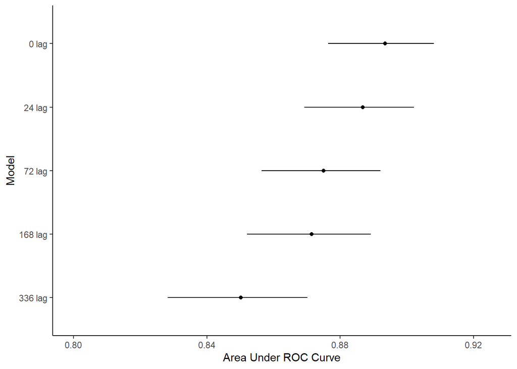

```r
test_metrics_all_pp_perf |>
  mutate(model = factor(model, levels = c("336 lag", "168 lag", "72 lag", "24 lag", "0 lag" ))) |>
  ggplot() +
  geom_point(aes(x = pp_median, y = model), color = "black") +
  geom_segment(mapping = aes(y = model, x = pp_lower, xend = pp_upper),
                data = test_metrics_all_pp_perf) +
  scale_x_continuous("Area Under ROC Curve", limits = c(.80, .925)) +
  ylab("Model") +
  theme_classic() +
  theme(legend.position = "none")
```

### Model Comparisons

#### Baseline Contrasts

```r
ci_baseline <- pp |>
  contrast_models(list("lag0", "lag0", "lag0", "lag0"),
                  list("lag24", "lag72", "lag168", "lag336")) |>
  summary(size = 0) |>
  mutate(contrast = factor(contrast,
                           levels = c("lag0 vs lag24", "lag0 vs lag72", "lag0 vs lag168",
                                      "lag0 vs lag336"),
                           labels = c("0 vs. 24", "0 vs. 72",
                                      "0 vs. 168", "0 vs. 336")))

ci_median_baseline <- pp |>
  contrast_models(list("lag0", "lag0", "lag0", "lag0"),
                  list("lag24", "lag72", "lag168", "lag336")) |>
  group_by(contrast) |>
  summarize(median = quantile(difference, .5)) |>
  mutate(contrast = factor(contrast,
                           levels = c("lag0 vs. lag24", "lag0 vs. lag72", "lag0 vs. lag168",
                                      "lag0 vs. lag336"),
                           labels = c("0 vs. 24", "0 vs. 72",
                                      "0 vs. 168", "0 vs. 336")))


ci_baseline <- ci_baseline |>
  left_join(ci_median_baseline, by = c("contrast"))

ci_baseline |>
  write_csv(file.path(path_models_lag, "ci_baseline.csv"))
```

The median decrease in auROC for the baseline vs. 24 hour lag model was 0.007 (95% CI=[0.001-0.012]), yielding a significant probability of 0.977 that the lagged model had worse performance. The median decrease in auROC for the baseline vs. 72 hour model was 0.018 (95% CI=[0.013-0.025]), yielding a significant probability of 1.000 that the lagged model had worse performance. The median increase in auROC for the baseline vs. 168 hour lag model was 0.022 (95% CI=[0.016-0.028]), yielding a significant probability of 1.000 that the lagged model had worse performance. The median increase in auROC for the baseline vs. 336 hour lag model was 0.043 (95% CI=[0.036-0.051]), yielding a significant probability of 1.000 that the lagged model had worse performance.

#### Adjacent Contrasts

```r
ci_lag <- pp |>
  contrast_models(list("lag24", "lag72", "lag168"),
                  list("lag72", "lag168", "lag336")) |>
  summary(size = 0) |>
  mutate(contrast = factor(contrast,
                           levels = c("lag24 vs lag72", "lag72 vs lag168",
                                      "lag168 vs lag336"),
                           labels = c("24 vs. 72", "72 vs. 168", "168 vs. 336")))

ci_median_lag <- pp |>
  contrast_models(list("lag24", "lag72", "lag168"),
                  list("lag72", "lag168", "lag336")) |>
  group_by(contrast) |>
  summarize(median = quantile(difference, .5)) |>
  mutate(contrast = factor(contrast,
                           levels = c("lag24 vs. lag72", "lag72 vs. lag168",
                                      "lag168 vs. lag336"),
                           labels = c("24 vs. 72", "72 vs. 168", "168 vs. 336")))

ci_lag <- ci_lag |>
  left_join(ci_median_lag, by = c("contrast"))

ci_lag |>
  write_csv(file.path(path_models_lag, "ci_lag.csv"))
```

The median decrease in auROC for the 24 hour vs. 72 hour lag model was 0.012 (95% CI=[0.006-0.018]), yielding a significant probability of 0.999 that the 72 hour lag model had worse performance than the 24 hour lag model. The median decrease in auROC for the 72 hour vs. 168 hour lag model was 0.003 (95% CI=[-0.002-0.010]), yielding a non-significant probability of 0.836 that the 168 hour lag model had worse performance than the 72 hour lag model. The median decrease in auROC for the 168 hour vs. 336 hour lag model was 0.021 (95% CI=[0.014-0.028]), yielding a significant probability of 1.000 that the 336 hour lag model had worse performance than the 168 hour lag model.